# xwMOOC 모형

나무모형과 생존분석의 만남

xwMOOC

2018-09-21

# 1 `ranger` 팩키지 [^1] [^2] [^3]

[`ranger`](https://github.com/imbs-hl/ranger) 팩키지 명칭은 “RANdom forest GEneRator”에서 나왔다. C++로 작성되어 매우 빠르고 문법도 깔끔하다. 특히, 생존분석(Survival Analysis)를 위해서 별도 작업 없이 … random forest 모형을 구축할 수 있다는 점에서 다른 팩키지 `randomForestSRC`와 비교하여 장점이 있다.

## 1.1 고객 이탈 데이터 [^4]

```r
> # 0. 팩키지 -----
> library(tidyverse)
> # 1. 데이터 -----
>
> download.file(url="https://cdn2.hubspot.net/hubfs/532045/Discriminant-analysis-churn-dataset.csv?t=1537486781722", destfile = "data/sgi-churn.csv")
>
> churn_dat <- read_csv("data/sgi-churn.csv")
>
> churn_df <- churn_dat %>%
+     mutate(churn = factor(churn, levels=c(0,1), labels = c("No", "Yes")))
>
> churn_df %>%
+     sample_frac(0.01) %>%
+     DT::datatable(options = list(scrollX = TRUE))
```

|  | account_length | number_vmail_messages | total_day_charge | total_eve_charge | total_night_charge | total_intl_charge | number_customer_service_calls | churn |
| --- | --- | --- | --- | --- | --- | --- | --- | --- |
| 1 | 60 | 0 | 31.11 | 17.57 | 9.17 | 3 | 1 | No |
| 2 | 107 | 0 | 43.81 | 13.3 | 4.7 | 2.65 | 1 | No |
| 3 | 123 | 0 | 35.17 | 19.07 | 8.88 | 2.24 | 3 | No |
| 4 | 50 | 22 | 42.99 | 15.12 | 7.13 | 2.3 | 3 | No |
| 5 | 154 | 35 | 38.08 | 16.32 | 7.34 | 2.59 | 0 | No |
| 6 | 144 | 26 | 30.11 | 17.51 | 11.47 | 1.78 | 2 | No |
| 7 | 121 | 21 | 21.47 | 17.82 | 8.66 | 2.86 | 1 | No |
| 8 | 123 | 31 | 34.61 | 13.34 | 10.63 | 3.24 | 1 | No |
| 9 | 130 | 0 | 42.84 | 14.47 | 9.41 | 1.54 | 0 | No |
| 10 | 82 | 24 | 26.38 | 20.78 | 5.51 | 2.89 | 1 | No |

[output cut: 40 more lines]

## 1.2 생존 랜덤 포레스트

생존분석을 위한 랜덤 포레스트 모형을 개발할 경우, `survival` 팩키지 `Surv(account_length, churn)` 객체를 생성한 후에 랜덤 포레스트 모형을 적합시킨다.

```r
> library(ranger)
> library(survival)
> library(extrafont)
> loadfonts()
> library(caret)
>
> ## 훈련/시험 데이터 분할 ----
> churn_idx <- createDataPartition(churn_df$churn, p=0.7, list=FALSE)
>
> train_df <- churn_df[churn_idx, ]
> test_df <- churn_df[-churn_idx, ]
>
> ## 랜덤포레스트 적합 ----
> churn_rf <- ranger(Surv(account_length, churn) ~ ., data=train_df,
+                     importance = "permutation", write.forest = TRUE)
```

### 1.2.1 중요변수

고객이탈 관련하여 중요한 변수를 random forest 모형의 Variable Importance를 통해 살펴본다.

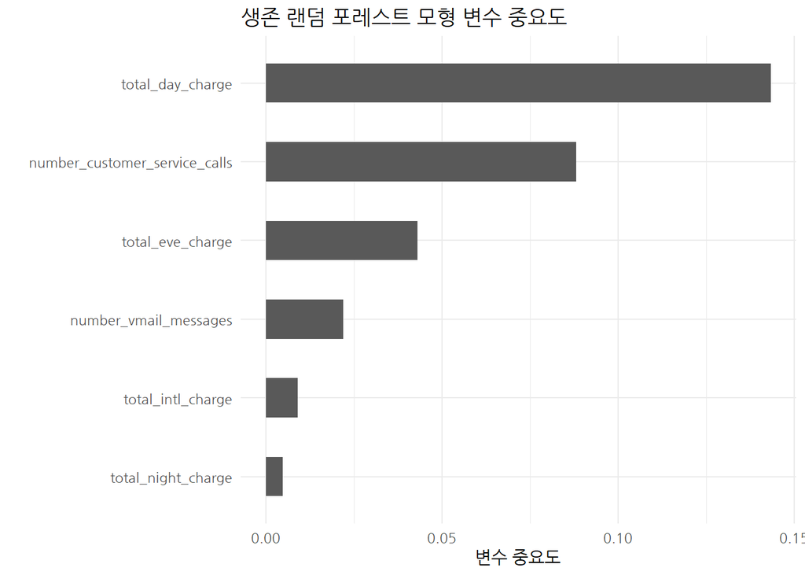

```r
> churn_varimp_df <- churn_rf$variable.importance %>% as.data.frame %>%
+     rownames_to_column(var="variable") %>%
+     rename(importance = ".")
>
> churn_varimp_df %>%
+     ggplot(aes(x=fct_reorder(variable, importance), y=importance)) +
+       geom_col(width=0.5) +
+       coord_flip() +
+       labs(x="", y="변수 중요도", title = "생존 랜덤 포레스트 모형 변수 중요도") +
+       theme_minimal(base_family = "NanumGothic")
```

### 1.2.2 고객별 잔존율 [^5]

고객 두명을 뽑아 예측모형에서 예측한 잔존율을 시각적으로 파악한다. 각 고객마다 잔존율을 물고 있어(`churn_rf$survival`), 이를 고개별로 바꾸고 고객을 추출하여 잔존율을 시각화한다.

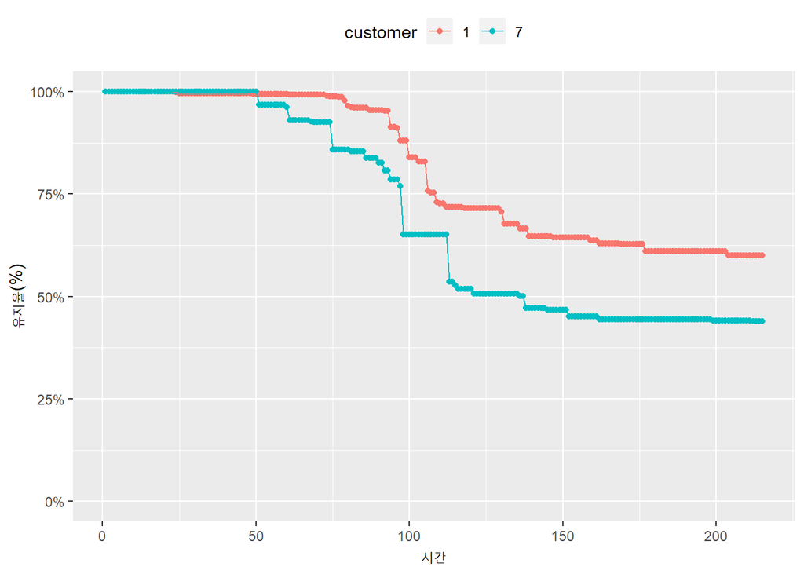

```r
> pred_df <- data.frame(churn_rf$survival) %>%
+   add_rownames(., var ="customer") %>%
+   gather(time, retention, -customer) %>%
+   spread(customer, retention)
>
>
> pred_df %>%
+   gather(customer, retention_prob, -time) %>%
+   mutate(time = str_remove(time, "X") %>% as.integer) %>%
+   filter(customer %in% c("1", "7")) %>%
+   ggplot(aes(x=time, y=retention_prob, group=customer, color=customer)) +
+     geom_point() +
+     geom_line() +
+     labs(x="시간", y="유지율(%)") +
+     scale_y_continuous(labels = scales::percent, limits=c(0,1)) +
+     theme(legend.position = "top")
```

### 1.2.3 모형 성능평가

앞서 분리한 시험데이터로 예측을 하고 이를 특시 시점 (30일)과 전체 기간에 대해서 AUC 값을 구해서 예측모형 성능을 확인한다.

```r
> library(Metrics)
> churn_pred <- predict(churn_rf, test_df)
>
> ## 30일 경과 AUC 성능
> auc(actual=as.integer(test_df$churn)-1, predicted=1 - churn_pred$survival[, which(churn_pred$unique.death.times==30)])
```

```
[1] 0.8036864
```

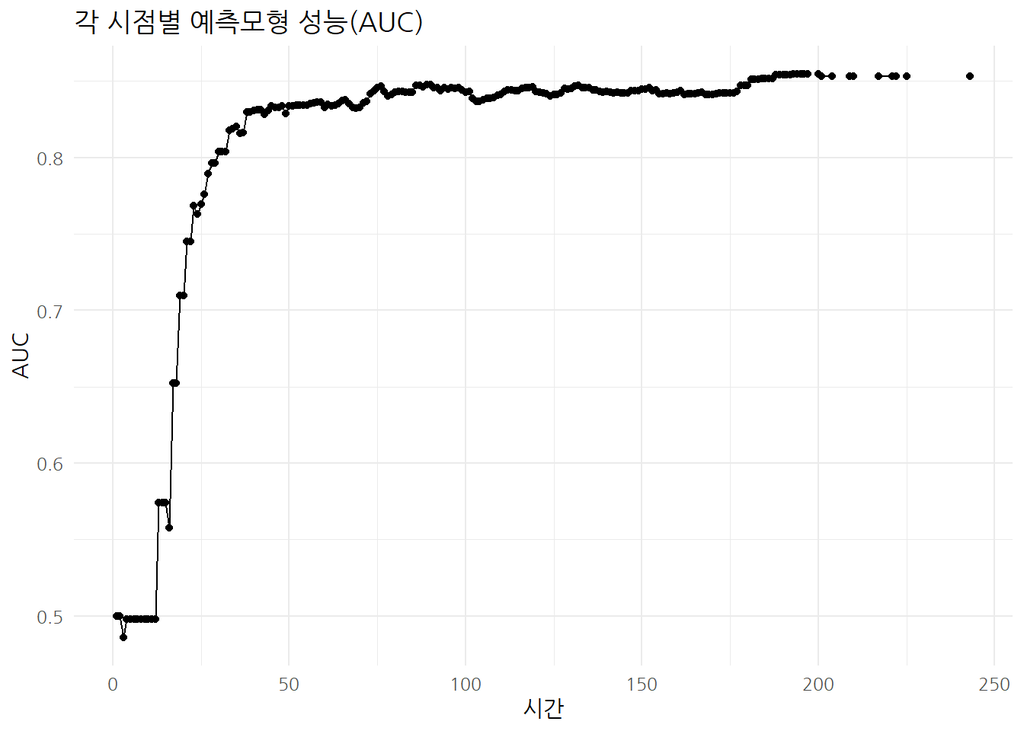

```r
> ## 전체 시점 AUC 성능
> auc_v <- vector("double", length = length(churn_pred$unique.death.times))
>
> for(i in seq_along(churn_pred$unique.death.times)) {
+   auc_v[i] <- auc(actual=as.integer(test_df$churn)-1, predicted=1 - churn_pred$survival[, which(churn_pred$unique.death.times==i)])
+ }
>
> churn_auc_df <- data.frame(time =churn_pred$unique.death.times, auc = auc_v)
>
> churn_auc_df %>%
+   ggplot(aes(x=time, y=auc)) +
+     geom_point() +
+     geom_line() +
+     labs(x="시간", y="AUC", title = "각 시점별 예측모형 성능(AUC)") +
+     theme_minimal(base_family = "NanumGothic")
```

[^1]: [climbeR: Calculate Average Minimal Depth of a Maximal Subtree for ‘ranger’ Package Forests](https://cran.r-project.org/web/packages/climbeR/vignettes/climbeR_examples.html)
[^2]: [Survival Ensembles: Survival Plus Classification for Improved Time-Based Predictions in R](https://amunategui.github.io/survival-ensembles/)
[^3]: [Survival Random Forests for Churn prediction](https://pedroconcejero.wordpress.com/2015/11/12/survival-random-forests-for-churn-prediction-3/)
[^4]: [Oracle, predicting-customer-churn-with-a-discriminant-analysis](https://www.datascience.com/blog/predicting-customer-churn-with-a-discriminant-analysis)
[^5]: [stackoverflow, “How to transpose a dataframe in tidyverse?”](https://stackoverflow.com/questions/40306280/how-to-transpose-a-dataframe-in-tidyverse)